# Ship or Iceberg - Preprocessing and EDA

# Introduction

This Kaggle competition’s goal is to use satellite images to distinguish ships from icebergs. From Kaggle:  
“Drifting icebergs present threats to navigation and activities in areas such as offshore of the East Coast of Canada.

Currently, many institutions and companies use aerial reconnaissance and shore-based support to monitor environmental conditions and assess risks from icebergs. However, in remote areas with particularly harsh weather, these methods are not feasible, and the only viable monitoring option is via satellite.

Statoil, an international energy company operating worldwide, has worked closely with companies like C-CORE. C-CORE have been using satellite data for over 30 years and have built a computer vision based surveillance system. To keep operations safe and efficient, Statoil is interested in getting a fresh new perspective on how to use machine learning to more accurately detect and discriminate against threatening icebergs as early as possible."

Sanchit and I hope to develop a representation learning model that can accurately classify these images. Let’s see if we can take a look at them and perform some EDA.

### Read in Data

The files are in JSON format, so they’re a little more interesting to deal with. Here we shall convert the JSON file to a data.table/frame.

```r
train <- lapply(X=train, fromJSON)
```

### Plot Image

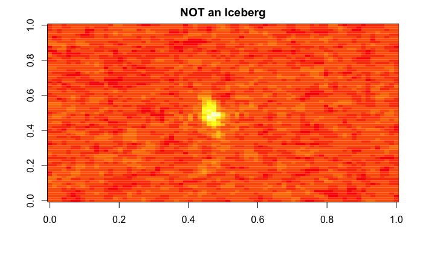